# Risk Factor Analysis

## Outcome Variable

**Outcome Variable:** ever_stunted

## Predictor Variables

**Intervention Variable:** hdlvry

**Adjustment Set:**

unadjusted

## Stratifying Variables

The analysis was stratified on these variable(s):

- agecat
- studyid
- country

## Data Summary

| agecat | studyid | country | A | n | nA | nAY0 | nAY1 |
| --- | --- | --- | --- | --- | --- | --- | --- |
| 3 months | ki1000108-CMC-V-BCS-2002 | INDIA | 0 | 359 | 352 | 230 | 122 |
| 3 months | ki1000108-CMC-V-BCS-2002 | INDIA | 1 | 359 | 7 | 5 | 2 |
| 3 months | ki1000108-IRC | INDIA | 0 | 410 | 402 | 274 | 128 |
| 3 months | ki1000108-IRC | INDIA | 1 | 410 | 8 | 6 | 2 |
| 3 months | ki1000109-EE | PAKISTAN | 0 | 377 | 253 | 95 | 158 |
| 3 months | ki1000109-EE | PAKISTAN | 1 | 377 | 124 | 42 | 82 |
| 3 months | ki1000304b-SAS-CompFeed | INDIA | 0 | 406 | 78 | 54 | 24 |
| 3 months | ki1000304b-SAS-CompFeed | INDIA | 1 | 406 | 328 | 216 | 112 |
| 3 months | ki1017093b-PROVIDE | BANGLADESH | 0 | 700 | 519 | 426 | 93 |
| 3 months | ki1017093b-PROVIDE | BANGLADESH | 1 | 700 | 181 | 144 | 37 |
| 3 months | ki1017093c-NIH-Crypto | BANGLADESH | 0 | 758 | 590 | 502 | 88 |
| 3 months | ki1017093c-NIH-Crypto | BANGLADESH | 1 | 758 | 168 | 135 | 33 |
| 3 months | ki1066203-TanzaniaChild2 | TANZANIA, UNITED REPUBLIC OF | 0 | 2271 | 2232 | 2015 | 217 |
| 3 months | ki1066203-TanzaniaChild2 | TANZANIA, UNITED REPUBLIC OF | 1 | 2271 | 39 | 32 | 7 |
| 3 months | ki1113344-GMS-Nepal | NEPAL | 0 | 552 | 135 | 118 | 17 |
| 3 months | ki1113344-GMS-Nepal | NEPAL | 1 | 552 | 417 | 348 | 69 |
| 3 months | ki1135781-COHORTS | INDIA | 0 | 4962 | 3057 | 2530 | 527 |
| 3 months | ki1135781-COHORTS | INDIA | 1 | 4962 | 1905 | 1483 | 422 |
| 3 months | kiGH5241-JiVitA-3 | BANGLADESH | 0 | 164 | 19 | 16 | 3 |
| 3 months | kiGH5241-JiVitA-3 | BANGLADESH | 1 | 164 | 145 | 98 | 47 |
| 3 months | kiGH5241-JiVitA-4 | BANGLADESH | 0 | 1146 | 276 | 215 | 61 |
| 3 months | kiGH5241-JiVitA-4 | BANGLADESH | 1 | 1146 | 870 | 619 | 251 |
| 6 months | ki1000108-CMC-V-BCS-2002 | INDIA | 0 | 364 | 357 | 172 | 185 |
| 6 months | ki1000108-CMC-V-BCS-2002 | INDIA | 1 | 364 | 7 | 5 | 2 |
| 6 months | ki1000108-IRC | INDIA | 0 | 408 | 400 | 231 | 169 |
| 6 months | ki1000108-IRC | INDIA | 1 | 408 | 8 | 4 | 4 |
| 6 months | ki1000109-EE | PAKISTAN | 0 | 371 | 250 | 65 | 185 |
| 6 months | ki1000109-EE | PAKISTAN | 1 | 371 | 121 | 31 | 90 |
| 6 months | ki1000304b-SAS-CompFeed | INDIA | 0 | 324 | 67 | 37 | 30 |
| 6 months | ki1000304b-SAS-CompFeed | INDIA | 1 | 324 | 257 | 148 | 109 |

[output cut: 80 more lines]

The following strata were considered:

- agecat: 12 months, studyid: ki1000108-CMC-V-BCS-2002, country: INDIA
- agecat: 12 months, studyid: ki1000108-IRC, country: INDIA
- agecat: 12 months, studyid: ki1000109-EE, country: PAKISTAN
- agecat: 12 months, studyid: ki1000304b-SAS-CompFeed, country: INDIA
- agecat: 12 months, studyid: ki1000304b-SAS-FoodSuppl, country: INDIA
- agecat: 12 months, studyid: ki1017093b-PROVIDE, country: BANGLADESH
- agecat: 12 months, studyid: ki1017093c-NIH-Crypto, country: BANGLADESH
- agecat: 12 months, studyid: ki1066203-TanzaniaChild2, country: TANZANIA, UNITED REPUBLIC OF
- agecat: 12 months, studyid: ki1113344-GMS-Nepal, country: NEPAL
- agecat: 12 months, studyid: ki1135781-COHORTS, country: INDIA
- agecat: 12 months, studyid: kiGH5241-JiVitA-3, country: BANGLADESH
- agecat: 12 months, studyid: kiGH5241-JiVitA-4, country: BANGLADESH
- agecat: 18 months, studyid: ki1000108-CMC-V-BCS-2002, country: INDIA
- agecat: 18 months, studyid: ki1000108-IRC, country: INDIA
- agecat: 18 months, studyid: ki1000109-EE, country: PAKISTAN
- agecat: 18 months, studyid: ki1000304b-SAS-CompFeed, country: INDIA
- agecat: 18 months, studyid: ki1000304b-SAS-FoodSuppl, country: INDIA
- agecat: 18 months, studyid: ki1017093b-PROVIDE, country: BANGLADESH
- agecat: 18 months, studyid: ki1017093c-NIH-Crypto, country: BANGLADESH
- agecat: 18 months, studyid: ki1066203-TanzaniaChild2, country: TANZANIA, UNITED REPUBLIC OF
- agecat: 18 months, studyid: ki1113344-GMS-Nepal, country: NEPAL
- agecat: 18 months, studyid: kiGH5241-JiVitA-3, country: BANGLADESH
- agecat: 18 months, studyid: kiGH5241-JiVitA-4, country: BANGLADESH
- agecat: 24 months, studyid: ki1000108-CMC-V-BCS-2002, country: INDIA
- agecat: 24 months, studyid: ki1000108-IRC, country: INDIA
- agecat: 24 months, studyid: ki1000109-EE, country: PAKISTAN
- agecat: 24 months, studyid: ki1000304b-SAS-CompFeed, country: INDIA
- agecat: 24 months, studyid: ki1000304b-SAS-FoodSuppl, country: INDIA
- agecat: 24 months, studyid: ki1017093b-PROVIDE, country: BANGLADESH
- agecat: 24 months, studyid: ki1017093c-NIH-Crypto, country: BANGLADESH
- agecat: 24 months, studyid: ki1066203-TanzaniaChild2, country: TANZANIA, UNITED REPUBLIC OF
- agecat: 24 months, studyid: ki1113344-GMS-Nepal, country: NEPAL
- agecat: 24 months, studyid: kiGH5241-JiVitA-4, country: BANGLADESH
- agecat: 3 months, studyid: ki1000108-CMC-V-BCS-2002, country: INDIA
- agecat: 3 months, studyid: ki1000108-IRC, country: INDIA
- agecat: 3 months, studyid: ki1000109-EE, country: PAKISTAN
- agecat: 3 months, studyid: ki1000304b-SAS-CompFeed, country: INDIA
- agecat: 3 months, studyid: ki1017093b-PROVIDE, country: BANGLADESH
- agecat: 3 months, studyid: ki1017093c-NIH-Crypto, country: BANGLADESH
- agecat: 3 months, studyid: ki1066203-TanzaniaChild2, country: TANZANIA, UNITED REPUBLIC OF
- agecat: 3 months, studyid: ki1113344-GMS-Nepal, country: NEPAL
- agecat: 3 months, studyid: ki1135781-COHORTS, country: INDIA
- agecat: 3 months, studyid: kiGH5241-JiVitA-3, country: BANGLADESH
- agecat: 3 months, studyid: kiGH5241-JiVitA-4, country: BANGLADESH
- agecat: 6 months, studyid: ki1000108-CMC-V-BCS-2002, country: INDIA
- agecat: 6 months, studyid: ki1000108-IRC, country: INDIA
- agecat: 6 months, studyid: ki1000109-EE, country: PAKISTAN
- agecat: 6 months, studyid: ki1000304b-SAS-CompFeed, country: INDIA
- agecat: 6 months, studyid: ki1000304b-SAS-FoodSuppl, country: INDIA
- agecat: 6 months, studyid: ki1017093b-PROVIDE, country: BANGLADESH
- agecat: 6 months, studyid: ki1017093c-NIH-Crypto, country: BANGLADESH
- agecat: 6 months, studyid: ki1066203-TanzaniaChild2, country: TANZANIA, UNITED REPUBLIC OF
- agecat: 6 months, studyid: ki1113344-GMS-Nepal, country: NEPAL
- agecat: 6 months, studyid: kiGH5241-JiVitA-3, country: BANGLADESH
- agecat: 6 months, studyid: kiGH5241-JiVitA-4, country: BANGLADESH

### Dropped Strata

Some strata were dropped due to rare outcomes:

- agecat: 3 months, studyid: ki1000108-CMC-V-BCS-2002, country: INDIA
- agecat: 3 months, studyid: ki1000108-IRC, country: INDIA
- agecat: 3 months, studyid: kiGH5241-JiVitA-3, country: BANGLADESH
- agecat: 6 months, studyid: ki1000108-CMC-V-BCS-2002, country: INDIA
- agecat: 6 months, studyid: ki1000108-IRC, country: INDIA
- agecat: 6 months, studyid: kiGH5241-JiVitA-3, country: BANGLADESH
- agecat: 12 months, studyid: ki1000108-CMC-V-BCS-2002, country: INDIA
- agecat: 12 months, studyid: ki1000108-IRC, country: INDIA
- agecat: 12 months, studyid: ki1000304b-SAS-FoodSuppl, country: INDIA
- agecat: 12 months, studyid: kiGH5241-JiVitA-3, country: BANGLADESH
- agecat: 18 months, studyid: ki1000108-CMC-V-BCS-2002, country: INDIA
- agecat: 18 months, studyid: ki1000108-IRC, country: INDIA
- agecat: 18 months, studyid: ki1000304b-SAS-FoodSuppl, country: INDIA
- agecat: 24 months, studyid: ki1000108-CMC-V-BCS-2002, country: INDIA
- agecat: 24 months, studyid: ki1000108-IRC, country: INDIA
- agecat: 24 months, studyid: ki1000109-EE, country: PAKISTAN
- agecat: 24 months, studyid: ki1000304b-SAS-CompFeed, country: INDIA
- agecat: 24 months, studyid: ki1000304b-SAS-FoodSuppl, country: INDIA

## Methods Detail

We’re interested in the causal parameters $E[Y_a]$ for all values of $a \in \mathcal{A}$. These parameters represent the mean outcome if, possibly contrary to fact, we intervened to set all units to have $A=a$. Under the randomization and positivity assumptions, these are identified by the statistical parameters $\psi_a=E_W[E_{Y|A,W}(Y|A=a,W)]$. In addition, we’re interested in the mean of $Y$, $E[Y]$ under no intervention (the observed mean). We will estimate these parameters by using SuperLearner to fit the relevant likelihood factors – $E_{Y|A,W}(Y|A=a,W)$ and $p(A=a|W)$, and then updating our likelihood fit using a joint TMLE.

For unadjusted analyses ($W=\{\}$), initial likelihoods were estimated using Lrnr_glm to estimate the simple $E(Y|A)$ and Lrnr_mean to estimate $p(A)$. For adjusted analyses, a small library containing Lrnr_glmnet, Lrnr_xgboost, and Lrnr_mean was used.

Having estimated these parameters, we will then use the delta method to estimate relative risks and attributable risks relative to a prespecified baseline level of $A$.

# Results Detail

## Results Plots

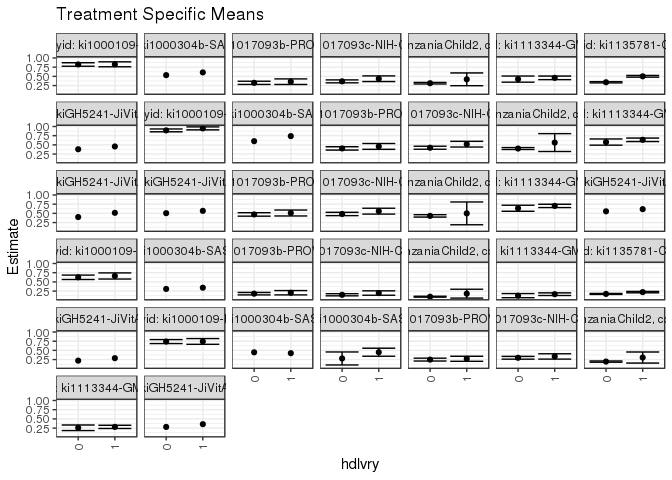

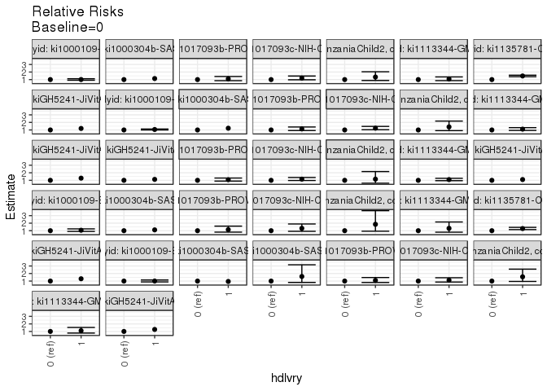

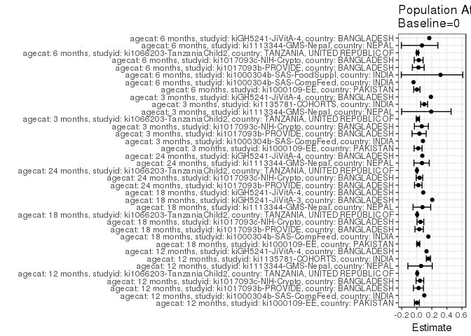

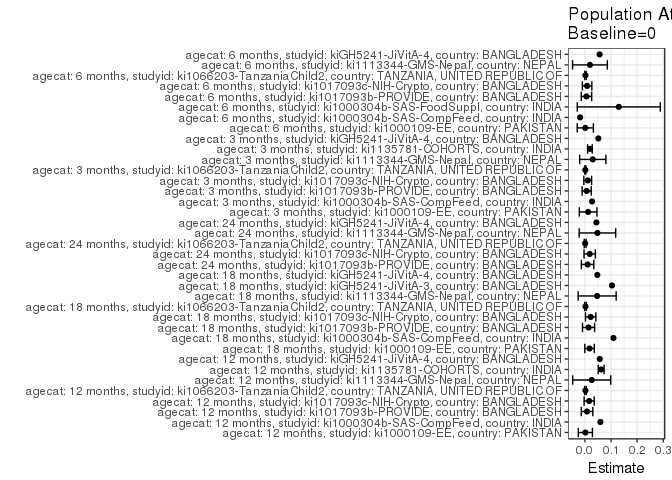

## Results Table

### Parameter: TSM

| agecat | studyid | country | intervention_level | baseline_level | estimate | ci_lower | ci_upper |
| --- | --- | --- | --- | --- | --- | --- | --- |
| 3 months | ki1000109-EE | PAKISTAN | 0 | NA | 0.6245059 | 0.5647564 | 0.6842554 |
| 3 months | ki1000109-EE | PAKISTAN | 1 | NA | 0.6612903 | 0.5778792 | 0.7447014 |
| 3 months | ki1000304b-SAS-CompFeed | INDIA | 0 | NA | 0.3076923 | NA | NA |
| 3 months | ki1000304b-SAS-CompFeed | INDIA | 1 | NA | 0.3414634 | NA | NA |
| 3 months | ki1017093b-PROVIDE | BANGLADESH | 0 | NA | 0.1791908 | 0.1461725 | 0.2122090 |
| 3 months | ki1017093b-PROVIDE | BANGLADESH | 1 | NA | 0.2044199 | 0.1456273 | 0.2632125 |
| 3 months | ki1017093c-NIH-Crypto | BANGLADESH | 0 | NA | 0.1491525 | 0.1203885 | 0.1779166 |
| 3 months | ki1017093c-NIH-Crypto | BANGLADESH | 1 | NA | 0.1964286 | 0.1363119 | 0.2565452 |
| 3 months | ki1066203-TanzaniaChild2 | TANZANIA, UNITED REPUBLIC OF | 0 | NA | 0.0972222 | 0.0849289 | 0.1095156 |
| 3 months | ki1066203-TanzaniaChild2 | TANZANIA, UNITED REPUBLIC OF | 1 | NA | 0.1794872 | 0.0590194 | 0.2999549 |
| 3 months | ki1113344-GMS-Nepal | NEPAL | 0 | NA | 0.1259259 | 0.0699106 | 0.1819412 |
| 3 months | ki1113344-GMS-Nepal | NEPAL | 1 | NA | 0.1654676 | 0.1297690 | 0.2011663 |
| 3 months | ki1135781-COHORTS | INDIA | 0 | NA | 0.1723912 | 0.1590002 | 0.1857823 |
| 3 months | ki1135781-COHORTS | INDIA | 1 | NA | 0.2215223 | 0.2028724 | 0.2401722 |
| 3 months | kiGH5241-JiVitA-4 | BANGLADESH | 0 | NA | 0.2210145 | NA | NA |
| 3 months | kiGH5241-JiVitA-4 | BANGLADESH | 1 | NA | 0.2885057 | NA | NA |
| 6 months | ki1000109-EE | PAKISTAN | 0 | NA | 0.7400000 | 0.6855539 | 0.7944461 |
| 6 months | ki1000109-EE | PAKISTAN | 1 | NA | 0.7438017 | 0.6659159 | 0.8216874 |
| 6 months | ki1000304b-SAS-CompFeed | INDIA | 0 | NA | 0.4477612 | NA | NA |
| 6 months | ki1000304b-SAS-CompFeed | INDIA | 1 | NA | 0.4241245 | NA | NA |
| 6 months | ki1000304b-SAS-FoodSuppl | INDIA | 0 | NA | 0.2800000 | 0.1031515 | 0.4568485 |
| 6 months | ki1000304b-SAS-FoodSuppl | INDIA | 1 | NA | 0.4500000 | 0.3404610 | 0.5595390 |
| 6 months | ki1017093b-PROVIDE | BANGLADESH | 0 | NA | 0.2489540 | 0.2101598 | 0.2877481 |
| 6 months | ki1017093b-PROVIDE | BANGLADESH | 1 | NA | 0.2716049 | 0.2030589 | 0.3401510 |
| 6 months | ki1017093c-NIH-Crypto | BANGLADESH | 0 | NA | 0.2989510 | 0.2614089 | 0.3364932 |
| 6 months | ki1017093c-NIH-Crypto | BANGLADESH | 1 | NA | 0.3353659 | 0.2630602 | 0.4076715 |
| 6 months | ki1066203-TanzaniaChild2 | TANZANIA, UNITED REPUBLIC OF | 0 | NA | 0.1952038 | 0.1781868 | 0.2122209 |
| 6 months | ki1066203-TanzaniaChild2 | TANZANIA, UNITED REPUBLIC OF | 1 | NA | 0.3055556 | 0.1550463 | 0.4560648 |
| 6 months | ki1113344-GMS-Nepal | NEPAL | 0 | NA | 0.2578125 | 0.1819615 | 0.3336635 |
| 6 months | ki1113344-GMS-Nepal | NEPAL | 1 | NA | 0.2828784 | 0.2388634 | 0.3268935 |
| 6 months | kiGH5241-JiVitA-4 | BANGLADESH | 0 | NA | 0.2812500 | NA | NA |
| 6 months | kiGH5241-JiVitA-4 | BANGLADESH | 1 | NA | 0.3561104 | NA | NA |
| 12 months | ki1000109-EE | PAKISTAN | 0 | NA | 0.8232932 | 0.7758539 | 0.8707325 |
| 12 months | ki1000109-EE | PAKISTAN | 1 | NA | 0.8278689 | 0.7607932 | 0.8949445 |
| 12 months | ki1000304b-SAS-CompFeed | INDIA | 0 | NA | 0.5333333 | NA | NA |
| 12 months | ki1000304b-SAS-CompFeed | INDIA | 1 | NA | 0.6075085 | NA | NA |
| 12 months | ki1017093b-PROVIDE | BANGLADESH | 0 | NA | 0.3237885 | 0.2807112 | 0.3668659 |
| 12 months | ki1017093b-PROVIDE | BANGLADESH | 1 | NA | 0.3548387 | 0.2794530 | 0.4302244 |
| 12 months | ki1017093c-NIH-Crypto | BANGLADESH | 0 | NA | 0.3639576 | 0.3242927 | 0.4036225 |
| 12 months | ki1017093c-NIH-Crypto | BANGLADESH | 1 | NA | 0.4355828 | 0.3594121 | 0.5117535 |
| 12 months | ki1066203-TanzaniaChild2 | TANZANIA, UNITED REPUBLIC OF | 0 | NA | 0.3134409 | 0.2923534 | 0.3345283 |
| 12 months | ki1066203-TanzaniaChild2 | TANZANIA, UNITED REPUBLIC OF | 1 | NA | 0.4193548 | 0.2456034 | 0.5931063 |
| 12 months | ki1113344-GMS-Nepal | NEPAL | 0 | NA | 0.4253731 | 0.3415867 | 0.5091596 |
| 12 months | ki1113344-GMS-Nepal | NEPAL | 1 | NA | 0.4596577 | 0.4113142 | 0.5080012 |
| 12 months | ki1135781-COHORTS | INDIA | 0 | NA | 0.3390236 | 0.3218784 | 0.3561687 |
| 12 months | ki1135781-COHORTS | INDIA | 1 | NA | 0.5011001 | 0.4781140 | 0.5240862 |
| 12 months | kiGH5241-JiVitA-4 | BANGLADESH | 0 | NA | 0.3809524 | NA | NA |
| 12 months | kiGH5241-JiVitA-4 | BANGLADESH | 1 | NA | 0.4566210 | NA | NA |
| 18 months | ki1000109-EE | PAKISTAN | 0 | NA | 0.8938776 | 0.8552577 | 0.9324974 |
| 18 months | ki1000109-EE | PAKISTAN | 1 | NA | 0.9482759 | 0.9079173 | 0.9886344 |
| 18 months | ki1000304b-SAS-CompFeed | INDIA | 0 | NA | 0.6000000 | NA | NA |
| 18 months | ki1000304b-SAS-CompFeed | INDIA | 1 | NA | 0.7377622 | NA | NA |
| 18 months | ki1017093b-PROVIDE | BANGLADESH | 0 | NA | 0.4035477 | 0.3582313 | 0.4488640 |
| 18 months | ki1017093b-PROVIDE | BANGLADESH | 1 | NA | 0.4575163 | 0.3785106 | 0.5365221 |
| 18 months | ki1017093c-NIH-Crypto | BANGLADESH | 0 | NA | 0.4216216 | 0.3805092 | 0.4627340 |
| 18 months | ki1017093c-NIH-Crypto | BANGLADESH | 1 | NA | 0.5187500 | 0.4412759 | 0.5962241 |
| 18 months | ki1066203-TanzaniaChild2 | TANZANIA, UNITED REPUBLIC OF | 0 | NA | 0.4002943 | 0.3742355 | 0.4263532 |
| 18 months | ki1066203-TanzaniaChild2 | TANZANIA, UNITED REPUBLIC OF | 1 | NA | 0.5625000 | 0.3193376 | 0.8056624 |
| 18 months | ki1113344-GMS-Nepal | NEPAL | 0 | NA | 0.5757576 | 0.4913669 | 0.6601482 |
| 18 months | ki1113344-GMS-Nepal | NEPAL | 1 | NA | 0.6377171 | 0.5907450 | 0.6846892 |
| 18 months | kiGH5241-JiVitA-3 | BANGLADESH | 0 | NA | 0.4000000 | NA | NA |
| 18 months | kiGH5241-JiVitA-3 | BANGLADESH | 1 | NA | 0.5149254 | NA | NA |
| 18 months | kiGH5241-JiVitA-4 | BANGLADESH | 0 | NA | 0.5052632 | NA | NA |
| 18 months | kiGH5241-JiVitA-4 | BANGLADESH | 1 | NA | 0.5684211 | NA | NA |
| 24 months | ki1017093b-PROVIDE | BANGLADESH | 0 | NA | 0.4711316 | 0.4240748 | 0.5181885 |
| 24 months | ki1017093b-PROVIDE | BANGLADESH | 1 | NA | 0.5100671 | 0.4297311 | 0.5904031 |
| 24 months | ki1017093c-NIH-Crypto | BANGLADESH | 0 | NA | 0.4834711 | 0.4389156 | 0.5280265 |
| 24 months | ki1017093c-NIH-Crypto | BANGLADESH | 1 | NA | 0.5600000 | 0.4805003 | 0.6394997 |
| 24 months | ki1066203-TanzaniaChild2 | TANZANIA, UNITED REPUBLIC OF | 0 | NA | 0.4319196 | 0.3994677 | 0.4643716 |
| 24 months | ki1066203-TanzaniaChild2 | TANZANIA, UNITED REPUBLIC OF | 1 | NA | 0.5000000 | 0.1899313 | 0.8100687 |
| 24 months | ki1113344-GMS-Nepal | NEPAL | 0 | NA | 0.6390977 | 0.5573999 | 0.7207956 |
| 24 months | ki1113344-GMS-Nepal | NEPAL | 1 | NA | 0.7027708 | 0.6577705 | 0.7477711 |
| 24 months | kiGH5241-JiVitA-4 | BANGLADESH | 0 | NA | 0.5560000 | NA | NA |
| 24 months | kiGH5241-JiVitA-4 | BANGLADESH | 1 | NA | 0.6143617 | NA | NA |

### Parameter: E(Y)

| agecat | studyid | country | intervention_level | baseline_level | estimate | ci_lower | ci_upper |
| --- | --- | --- | --- | --- | --- | --- | --- |
| 3 months | ki1000109-EE | PAKISTAN | NA | NA | 0.6366048 | 0.5879888 | 0.6852207 |
| 3 months | ki1000304b-SAS-CompFeed | INDIA | NA | NA | 0.3349754 | NA | NA |
| 3 months | ki1017093b-PROVIDE | BANGLADESH | NA | NA | 0.1857143 | 0.1568859 | 0.2145427 |
| 3 months | ki1017093c-NIH-Crypto | BANGLADESH | NA | NA | 0.1596306 | 0.1335394 | 0.1857218 |
| 3 months | ki1066203-TanzaniaChild2 | TANZANIA, UNITED REPUBLIC OF | NA | NA | 0.0986350 | 0.0863690 | 0.1109009 |
| 3 months | ki1113344-GMS-Nepal | NEPAL | NA | NA | 0.1557971 | 0.1255157 | 0.1860785 |
| 3 months | ki1135781-COHORTS | INDIA | NA | NA | 0.1912535 | 0.1803096 | 0.2021975 |
| 3 months | kiGH5241-JiVitA-4 | BANGLADESH | NA | NA | 0.2722513 | NA | NA |
| 6 months | ki1000109-EE | PAKISTAN | NA | NA | 0.7412399 | 0.6966152 | 0.7858646 |
| 6 months | ki1000304b-SAS-CompFeed | INDIA | NA | NA | 0.4290123 | NA | NA |
| 6 months | ki1000304b-SAS-FoodSuppl | INDIA | NA | NA | 0.4095238 | 0.3150150 | 0.5040326 |
| 6 months | ki1017093b-PROVIDE | BANGLADESH | NA | NA | 0.2546875 | 0.2209066 | 0.2884684 |
| 6 months | ki1017093c-NIH-Crypto | BANGLADESH | NA | NA | 0.3070652 | 0.2737175 | 0.3404129 |
| 6 months | ki1066203-TanzaniaChild2 | TANZANIA, UNITED REPUBLIC OF | NA | NA | 0.1970769 | 0.1801438 | 0.2140099 |
| 6 months | ki1113344-GMS-Nepal | NEPAL | NA | NA | 0.2768362 | 0.2387436 | 0.3149287 |
| 6 months | kiGH5241-JiVitA-4 | BANGLADESH | NA | NA | 0.3372665 | NA | NA |
| 12 months | ki1000109-EE | PAKISTAN | NA | NA | 0.8247978 | 0.7860640 | 0.8635317 |
| 12 months | ki1000304b-SAS-CompFeed | INDIA | NA | NA | 0.5923913 | NA | NA |
| 12 months | ki1017093b-PROVIDE | BANGLADESH | NA | NA | 0.3316913 | 0.2942672 | 0.3691154 |
| 12 months | ki1017093c-NIH-Crypto | BANGLADESH | NA | NA | 0.3799726 | 0.3447141 | 0.4152311 |
| 12 months | ki1066203-TanzaniaChild2 | TANZANIA, UNITED REPUBLIC OF | NA | NA | 0.3151772 | 0.2942320 | 0.3361223 |
| 12 months | ki1113344-GMS-Nepal | NEPAL | NA | NA | 0.4511971 | 0.4093042 | 0.4930899 |
| 12 months | ki1135781-COHORTS | INDIA | NA | NA | 0.4010954 | 0.3871514 | 0.4150394 |
| 12 months | kiGH5241-JiVitA-4 | BANGLADESH | NA | NA | 0.4376068 | NA | NA |
| 18 months | ki1000109-EE | PAKISTAN | NA | NA | 0.9113573 | 0.8819969 | 0.9407178 |
| 18 months | ki1000304b-SAS-CompFeed | INDIA | NA | NA | 0.7091413 | NA | NA |
| 18 months | ki1017093b-PROVIDE | BANGLADESH | NA | NA | 0.4172185 | 0.3778614 | 0.4565757 |
| 18 months | ki1017093c-NIH-Crypto | BANGLADESH | NA | NA | 0.4433566 | 0.4069178 | 0.4797954 |
| 18 months | ki1066203-TanzaniaChild2 | TANZANIA, UNITED REPUBLIC OF | NA | NA | 0.4021818 | 0.3762549 | 0.4281087 |
| 18 months | ki1113344-GMS-Nepal | NEPAL | NA | NA | 0.6224299 | 0.5813129 | 0.6635469 |
| 18 months | kiGH5241-JiVitA-3 | BANGLADESH | NA | NA | 0.5033557 | NA | NA |
| 18 months | kiGH5241-JiVitA-4 | BANGLADESH | NA | NA | 0.5526316 | NA | NA |
| 24 months | ki1017093b-PROVIDE | BANGLADESH | NA | NA | 0.4810997 | 0.4404722 | 0.5217271 |
| 24 months | ki1017093c-NIH-Crypto | BANGLADESH | NA | NA | 0.5015773 | 0.4626267 | 0.5405279 |
| 24 months | ki1066203-TanzaniaChild2 | TANZANIA, UNITED REPUBLIC OF | NA | NA | 0.4326711 | 0.4003921 | 0.4649501 |
| 24 months | ki1113344-GMS-Nepal | NEPAL | NA | NA | 0.6867925 | 0.6472695 | 0.7263154 |
| 24 months | kiGH5241-JiVitA-4 | BANGLADESH | NA | NA | 0.5998004 | NA | NA |

### Parameter: RR

| agecat | studyid | country | intervention_level | baseline_level | estimate | ci_lower | ci_upper |
| --- | --- | --- | --- | --- | --- | --- | --- |
| 3 months | ki1000109-EE | PAKISTAN | 0 | 0 | 1.0000000 | 1.0000000 | 1.000000 |
| 3 months | ki1000109-EE | PAKISTAN | 1 | 0 | 1.0589016 | 0.9038587 | 1.240540 |
| 3 months | ki1000304b-SAS-CompFeed | INDIA | 0 | 0 | 1.0000000 | NA | NA |
| 3 months | ki1000304b-SAS-CompFeed | INDIA | 1 | 0 | 1.1097561 | NA | NA |
| 3 months | ki1017093b-PROVIDE | BANGLADESH | 0 | 0 | 1.0000000 | 1.0000000 | 1.000000 |
| 3 months | ki1017093b-PROVIDE | BANGLADESH | 1 | 0 | 1.1407949 | 0.8107094 | 1.605277 |
| 3 months | ki1017093c-NIH-Crypto | BANGLADESH | 0 | 0 | 1.0000000 | 1.0000000 | 1.000000 |
| 3 months | ki1017093c-NIH-Crypto | BANGLADESH | 1 | 0 | 1.3169643 | 0.9172164 | 1.890933 |
| 3 months | ki1066203-TanzaniaChild2 | TANZANIA, UNITED REPUBLIC OF | 0 | 0 | 1.0000000 | 1.0000000 | 1.000000 |
| 3 months | ki1066203-TanzaniaChild2 | TANZANIA, UNITED REPUBLIC OF | 1 | 0 | 1.8461538 | 0.9325057 | 3.654974 |
| 3 months | ki1113344-GMS-Nepal | NEPAL | 0 | 0 | 1.0000000 | 1.0000000 | 1.000000 |
| 3 months | ki1113344-GMS-Nepal | NEPAL | 1 | 0 | 1.3140076 | 0.8014733 | 2.154303 |
| 3 months | ki1135781-COHORTS | INDIA | 0 | 0 | 1.0000000 | 1.0000000 | 1.000000 |
| 3 months | ki1135781-COHORTS | INDIA | 1 | 0 | 1.2849975 | 1.1459184 | 1.440957 |
| 3 months | kiGH5241-JiVitA-4 | BANGLADESH | 0 | 0 | 1.0000000 | NA | NA |
| 3 months | kiGH5241-JiVitA-4 | BANGLADESH | 1 | 0 | 1.3053703 | NA | NA |
| 6 months | ki1000109-EE | PAKISTAN | 0 | 0 | 1.0000000 | 1.0000000 | 1.000000 |
| 6 months | ki1000109-EE | PAKISTAN | 1 | 0 | 1.0051374 | 0.8843934 | 1.142366 |
| 6 months | ki1000304b-SAS-CompFeed | INDIA | 0 | 0 | 1.0000000 | NA | NA |
| 6 months | ki1000304b-SAS-CompFeed | INDIA | 1 | 0 | 0.9472114 | NA | NA |
| 6 months | ki1000304b-SAS-FoodSuppl | INDIA | 0 | 0 | 1.0000000 | 1.0000000 | 1.000000 |
| 6 months | ki1000304b-SAS-FoodSuppl | INDIA | 1 | 0 | 1.6071429 | 0.8167457 | 3.162439 |
| 6 months | ki1017093b-PROVIDE | BANGLADESH | 0 | 0 | 1.0000000 | 1.0000000 | 1.000000 |
| 6 months | ki1017093b-PROVIDE | BANGLADESH | 1 | 0 | 1.0909845 | 0.8109688 | 1.467686 |
| 6 months | ki1017093c-NIH-Crypto | BANGLADESH | 0 | 0 | 1.0000000 | 1.0000000 | 1.000000 |
| 6 months | ki1017093c-NIH-Crypto | BANGLADESH | 1 | 0 | 1.1218086 | 0.8740947 | 1.439723 |
| 6 months | ki1066203-TanzaniaChild2 | TANZANIA, UNITED REPUBLIC OF | 0 | 0 | 1.0000000 | 1.0000000 | 1.000000 |
| 6 months | ki1066203-TanzaniaChild2 | TANZANIA, UNITED REPUBLIC OF | 1 | 0 | 1.5653153 | 0.9491931 | 2.581363 |
| 6 months | ki1113344-GMS-Nepal | NEPAL | 0 | 0 | 1.0000000 | 1.0000000 | 1.000000 |
| 6 months | ki1113344-GMS-Nepal | NEPAL | 1 | 0 | 1.0972254 | 0.7865991 | 1.530517 |
| 6 months | kiGH5241-JiVitA-4 | BANGLADESH | 0 | 0 | 1.0000000 | NA | NA |
| 6 months | kiGH5241-JiVitA-4 | BANGLADESH | 1 | 0 | 1.2661702 | NA | NA |
| 12 months | ki1000109-EE | PAKISTAN | 0 | 0 | 1.0000000 | 1.0000000 | 1.000000 |
| 12 months | ki1000109-EE | PAKISTAN | 1 | 0 | 1.0055578 | 0.9103921 | 1.110671 |
| 12 months | ki1000304b-SAS-CompFeed | INDIA | 0 | 0 | 1.0000000 | NA | NA |
| 12 months | ki1000304b-SAS-CompFeed | INDIA | 1 | 0 | 1.1390785 | NA | NA |
| 12 months | ki1017093b-PROVIDE | BANGLADESH | 0 | 0 | 1.0000000 | 1.0000000 | 1.000000 |
| 12 months | ki1017093b-PROVIDE | BANGLADESH | 1 | 0 | 1.0958964 | 0.8529136 | 1.408101 |
| 12 months | ki1017093c-NIH-Crypto | BANGLADESH | 0 | 0 | 1.0000000 | 1.0000000 | 1.000000 |
| 12 months | ki1017093c-NIH-Crypto | BANGLADESH | 1 | 0 | 1.1967955 | 0.9739424 | 1.470641 |
| 12 months | ki1066203-TanzaniaChild2 | TANZANIA, UNITED REPUBLIC OF | 0 | 0 | 1.0000000 | 1.0000000 | 1.000000 |
| 12 months | ki1066203-TanzaniaChild2 | TANZANIA, UNITED REPUBLIC OF | 1 | 0 | 1.3379074 | 0.8792816 | 2.035748 |
| 12 months | ki1113344-GMS-Nepal | NEPAL | 0 | 0 | 1.0000000 | 1.0000000 | 1.000000 |
| 12 months | ki1113344-GMS-Nepal | NEPAL | 1 | 0 | 1.0805988 | 0.8643509 | 1.350949 |
| 12 months | ki1135781-COHORTS | INDIA | 0 | 0 | 1.0000000 | 1.0000000 | 1.000000 |
| 12 months | ki1135781-COHORTS | INDIA | 1 | 0 | 1.4780687 | 1.3805189 | 1.582512 |
| 12 months | kiGH5241-JiVitA-4 | BANGLADESH | 0 | 0 | 1.0000000 | NA | NA |
| 12 months | kiGH5241-JiVitA-4 | BANGLADESH | 1 | 0 | 1.1986301 | NA | NA |
| 18 months | ki1000109-EE | PAKISTAN | 0 | 0 | 1.0000000 | 1.0000000 | 1.000000 |
| 18 months | ki1000109-EE | PAKISTAN | 1 | 0 | 1.0608566 | 0.9984314 | 1.127185 |
| 18 months | ki1000304b-SAS-CompFeed | INDIA | 0 | 0 | 1.0000000 | NA | NA |
| 18 months | ki1000304b-SAS-CompFeed | INDIA | 1 | 0 | 1.2296037 | NA | NA |
| 18 months | ki1017093b-PROVIDE | BANGLADESH | 0 | 0 | 1.0000000 | 1.0000000 | 1.000000 |
| 18 months | ki1017093b-PROVIDE | BANGLADESH | 1 | 0 | 1.1337355 | 0.9226851 | 1.393061 |
| 18 months | ki1017093c-NIH-Crypto | BANGLADESH | 0 | 0 | 1.0000000 | 1.0000000 | 1.000000 |
| 18 months | ki1017093c-NIH-Crypto | BANGLADESH | 1 | 0 | 1.2303686 | 1.0293751 | 1.470608 |
| 18 months | ki1066203-TanzaniaChild2 | TANZANIA, UNITED REPUBLIC OF | 0 | 0 | 1.0000000 | 1.0000000 | 1.000000 |
| 18 months | ki1066203-TanzaniaChild2 | TANZANIA, UNITED REPUBLIC OF | 1 | 0 | 1.4052160 | 0.9075815 | 2.175708 |
| 18 months | ki1113344-GMS-Nepal | NEPAL | 0 | 0 | 1.0000000 | 1.0000000 | 1.000000 |
| 18 months | ki1113344-GMS-Nepal | NEPAL | 1 | 0 | 1.1076139 | 0.9400412 | 1.305058 |
| 18 months | kiGH5241-JiVitA-3 | BANGLADESH | 0 | 0 | 1.0000000 | NA | NA |
| 18 months | kiGH5241-JiVitA-3 | BANGLADESH | 1 | 0 | 1.2873134 | NA | NA |
| 18 months | kiGH5241-JiVitA-4 | BANGLADESH | 0 | 0 | 1.0000000 | NA | NA |
| 18 months | kiGH5241-JiVitA-4 | BANGLADESH | 1 | 0 | 1.1250000 | NA | NA |
| 24 months | ki1017093b-PROVIDE | BANGLADESH | 0 | 0 | 1.0000000 | 1.0000000 | 1.000000 |
| 24 months | ki1017093b-PROVIDE | BANGLADESH | 1 | 0 | 1.0826425 | 0.8984392 | 1.304612 |
| 24 months | ki1017093c-NIH-Crypto | BANGLADESH | 0 | 0 | 1.0000000 | 1.0000000 | 1.000000 |
| 24 months | ki1017093c-NIH-Crypto | BANGLADESH | 1 | 0 | 1.1582906 | 0.9779389 | 1.371903 |
| 24 months | ki1066203-TanzaniaChild2 | TANZANIA, UNITED REPUBLIC OF | 0 | 0 | 1.0000000 | 1.0000000 | 1.000000 |
| 24 months | ki1066203-TanzaniaChild2 | TANZANIA, UNITED REPUBLIC OF | 1 | 0 | 1.1576227 | 0.6198339 | 2.162015 |
| 24 months | ki1113344-GMS-Nepal | NEPAL | 0 | 0 | 1.0000000 | 1.0000000 | 1.000000 |
| 24 months | ki1113344-GMS-Nepal | NEPAL | 1 | 0 | 1.0996296 | 0.9531334 | 1.268642 |
| 24 months | kiGH5241-JiVitA-4 | BANGLADESH | 0 | 0 | 1.0000000 | NA | NA |
| 24 months | kiGH5241-JiVitA-4 | BANGLADESH | 1 | 0 | 1.1049671 | NA | NA |

### Parameter: PAR

| agecat | studyid | country | intervention_level | baseline_level | estimate | ci_lower | ci_upper |
| --- | --- | --- | --- | --- | --- | --- | --- |
| 3 months | ki1000109-EE | PAKISTAN | 0 | NA | 0.0120988 | -0.0216938 | 0.0458915 |
| 3 months | ki1000304b-SAS-CompFeed | INDIA | 0 | NA | 0.0272831 | NA | NA |
| 3 months | ki1017093b-PROVIDE | BANGLADESH | 0 | NA | 0.0065235 | -0.0109311 | 0.0239782 |
| 3 months | ki1017093c-NIH-Crypto | BANGLADESH | 0 | NA | 0.0104781 | -0.0043587 | 0.0253148 |
| 3 months | ki1066203-TanzaniaChild2 | TANZANIA, UNITED REPUBLIC OF | 0 | NA | 0.0014127 | -0.0007128 | 0.0035383 |
| 3 months | ki1113344-GMS-Nepal | NEPAL | 0 | NA | 0.0298712 | -0.0203277 | 0.0800700 |
| 3 months | ki1135781-COHORTS | INDIA | 0 | NA | 0.0188623 | 0.0100227 | 0.0277019 |
| 3 months | kiGH5241-JiVitA-4 | BANGLADESH | 0 | NA | 0.0512368 | NA | NA |
| 6 months | ki1000109-EE | PAKISTAN | 0 | NA | 0.0012399 | -0.0297540 | 0.0322338 |
| 6 months | ki1000304b-SAS-CompFeed | INDIA | 0 | NA | -0.0187488 | NA | NA |
| 6 months | ki1000304b-SAS-FoodSuppl | INDIA | 0 | NA | 0.1295238 | -0.0295807 | 0.2886284 |
| 6 months | ki1017093b-PROVIDE | BANGLADESH | 0 | NA | 0.0057335 | -0.0142179 | 0.0256849 |
| 6 months | ki1017093c-NIH-Crypto | BANGLADESH | 0 | NA | 0.0081142 | -0.0100727 | 0.0263011 |
| 6 months | ki1066203-TanzaniaChild2 | TANZANIA, UNITED REPUBLIC OF | 0 | NA | 0.0018730 | -0.0007685 | 0.0045145 |
| 6 months | ki1113344-GMS-Nepal | NEPAL | 0 | NA | 0.0190237 | -0.0475395 | 0.0855869 |
| 6 months | kiGH5241-JiVitA-4 | BANGLADESH | 0 | NA | 0.0560165 | NA | NA |
| 12 months | ki1000109-EE | PAKISTAN | 0 | NA | 0.0015047 | -0.0255125 | 0.0285219 |
| 12 months | ki1000304b-SAS-CompFeed | INDIA | 0 | NA | 0.0590580 | NA | NA |
| 12 months | ki1017093b-PROVIDE | BANGLADESH | 0 | NA | 0.0079028 | -0.0142218 | 0.0300273 |
| 12 months | ki1017093c-NIH-Crypto | BANGLADESH | 0 | NA | 0.0160150 | -0.0033091 | 0.0353391 |
| 12 months | ki1066203-TanzaniaChild2 | TANZANIA, UNITED REPUBLIC OF | 0 | NA | 0.0017363 | -0.0011964 | 0.0046689 |
| 12 months | ki1113344-GMS-Nepal | NEPAL | 0 | NA | 0.0258239 | -0.0470482 | 0.0986960 |
| 12 months | ki1135781-COHORTS | INDIA | 0 | NA | 0.0620719 | 0.0508631 | 0.0732806 |
| 12 months | kiGH5241-JiVitA-4 | BANGLADESH | 0 | NA | 0.0566545 | NA | NA |
| 18 months | ki1000109-EE | PAKISTAN | 0 | NA | 0.0174798 | -0.0006604 | 0.0356200 |
| 18 months | ki1000304b-SAS-CompFeed | INDIA | 0 | NA | 0.1091413 | NA | NA |
| 18 months | ki1017093b-PROVIDE | BANGLADESH | 0 | NA | 0.0136709 | -0.0094765 | 0.0368183 |
| 18 months | ki1017093c-NIH-Crypto | BANGLADESH | 0 | NA | 0.0217350 | 0.0018850 | 0.0415850 |
| 18 months | ki1066203-TanzaniaChild2 | TANZANIA, UNITED REPUBLIC OF | 0 | NA | 0.0018875 | -0.0011032 | 0.0048782 |
| 18 months | ki1113344-GMS-Nepal | NEPAL | 0 | NA | 0.0466723 | -0.0261156 | 0.1194603 |
| 18 months | kiGH5241-JiVitA-3 | BANGLADESH | 0 | NA | 0.1033557 | NA | NA |
| 18 months | kiGH5241-JiVitA-4 | BANGLADESH | 0 | NA | 0.0473684 | NA | NA |
| 24 months | ki1017093b-PROVIDE | BANGLADESH | 0 | NA | 0.0099680 | -0.0139077 | 0.0338438 |
| 24 months | ki1017093c-NIH-Crypto | BANGLADESH | 0 | NA | 0.0181062 | -0.0036038 | 0.0398162 |
| 24 months | ki1066203-TanzaniaChild2 | TANZANIA, UNITED REPUBLIC OF | 0 | NA | 0.0007514 | -0.0027207 | 0.0042236 |
| 24 months | ki1113344-GMS-Nepal | NEPAL | 0 | NA | 0.0476947 | -0.0222105 | 0.1175999 |
| 24 months | kiGH5241-JiVitA-4 | BANGLADESH | 0 | NA | 0.0438004 | NA | NA |

### Parameter: PAF

| agecat | studyid | country | intervention_level | baseline_level | estimate | ci_lower | ci_upper |
| --- | --- | --- | --- | --- | --- | --- | --- |
| 3 months | ki1000109-EE | PAKISTAN | 0 | NA | 0.0190053 | -0.0355908 | 0.0707231 |
| 3 months | ki1000304b-SAS-CompFeed | INDIA | 0 | NA | 0.0814480 | NA | NA |
| 3 months | ki1017093b-PROVIDE | BANGLADESH | 0 | NA | 0.0351267 | -0.0634920 | 0.1246004 |
| 3 months | ki1017093c-NIH-Crypto | BANGLADESH | 0 | NA | 0.0656394 | -0.0316425 | 0.1537479 |
| 3 months | ki1066203-TanzaniaChild2 | TANZANIA, UNITED REPUBLIC OF | 0 | NA | 0.0143229 | -0.0074045 | 0.0355818 |
| 3 months | ki1113344-GMS-Nepal | NEPAL | 0 | NA | 0.1917313 | -0.2018979 | 0.4564444 |
| 3 months | ki1135781-COHORTS | INDIA | 0 | NA | 0.0986246 | 0.0514083 | 0.1434906 |
| 3 months | kiGH5241-JiVitA-4 | BANGLADESH | 0 | NA | 0.1881968 | NA | NA |
| 6 months | ki1000109-EE | PAKISTAN | 0 | NA | 0.0016727 | -0.0410295 | 0.0426233 |
| 6 months | ki1000304b-SAS-CompFeed | INDIA | 0 | NA | -0.0437024 | NA | NA |
| 6 months | ki1000304b-SAS-FoodSuppl | INDIA | 0 | NA | 0.3162791 | -0.2062390 | 0.6124530 |
| 6 months | ki1017093b-PROVIDE | BANGLADESH | 0 | NA | 0.0225120 | -0.0590289 | 0.0977746 |
| 6 months | ki1017093c-NIH-Crypto | BANGLADESH | 0 | NA | 0.0264249 | -0.0346317 | 0.0838784 |
| 6 months | ki1066203-TanzaniaChild2 | TANZANIA, UNITED REPUBLIC OF | 0 | NA | 0.0095040 | -0.0039777 | 0.0228046 |
| 6 months | ki1113344-GMS-Nepal | NEPAL | 0 | NA | 0.0687181 | -0.2055477 | 0.2805876 |
| 6 months | kiGH5241-JiVitA-4 | BANGLADESH | 0 | NA | 0.1660897 | NA | NA |
| 12 months | ki1000109-EE | PAKISTAN | 0 | NA | 0.0018243 | -0.0314762 | 0.0340497 |
| 12 months | ki1000304b-SAS-CompFeed | INDIA | 0 | NA | 0.0996942 | NA | NA |
| 12 months | ki1017093b-PROVIDE | BANGLADESH | 0 | NA | 0.0238256 | -0.0452065 | 0.0882985 |
| 12 months | ki1017093c-NIH-Crypto | BANGLADESH | 0 | NA | 0.0421477 | -0.0101108 | 0.0917026 |
| 12 months | ki1066203-TanzaniaChild2 | TANZANIA, UNITED REPUBLIC OF | 0 | NA | 0.0055089 | -0.0038389 | 0.0147697 |
| 12 months | ki1113344-GMS-Nepal | NEPAL | 0 | NA | 0.0572342 | -0.1189906 | 0.2057062 |
| 12 months | ki1135781-COHORTS | INDIA | 0 | NA | 0.1547559 | 0.1262728 | 0.1823104 |
| 12 months | kiGH5241-JiVitA-4 | BANGLADESH | 0 | NA | 0.1294643 | NA | NA |
| 18 months | ki1000109-EE | PAKISTAN | 0 | NA | 0.0191800 | -0.0011147 | 0.0390632 |
| 18 months | ki1000304b-SAS-CompFeed | INDIA | 0 | NA | 0.1539062 | NA | NA |
| 18 months | ki1017093b-PROVIDE | BANGLADESH | 0 | NA | 0.0327667 | -0.0243707 | 0.0867171 |
| 18 months | ki1017093c-NIH-Crypto | BANGLADESH | 0 | NA | 0.0490238 | 0.0030833 | 0.0928472 |
| 18 months | ki1066203-TanzaniaChild2 | TANZANIA, UNITED REPUBLIC OF | 0 | NA | 0.0046931 | -0.0027730 | 0.0121036 |
| 18 months | ki1113344-GMS-Nepal | NEPAL | 0 | NA | 0.0749841 | -0.0499149 | 0.1850250 |
| 18 months | kiGH5241-JiVitA-3 | BANGLADESH | 0 | NA | 0.2053333 | NA | NA |
| 18 months | kiGH5241-JiVitA-4 | BANGLADESH | 0 | NA | 0.0857143 | NA | NA |
| 24 months | ki1017093b-PROVIDE | BANGLADESH | 0 | NA | 0.0207192 | -0.0302137 | 0.0691340 |
| 24 months | ki1017093c-NIH-Crypto | BANGLADESH | 0 | NA | 0.0360985 | -0.0082606 | 0.0785061 |
| 24 months | ki1066203-TanzaniaChild2 | TANZANIA, UNITED REPUBLIC OF | 0 | NA | 0.0017367 | -0.0063211 | 0.0097300 |
| 24 months | ki1113344-GMS-Nepal | NEPAL | 0 | NA | 0.0694456 | -0.0383842 | 0.1660779 |
| 24 months | kiGH5241-JiVitA-4 | BANGLADESH | 0 | NA | 0.0730250 | NA | NA |